# Capstone Milestone

Dan Berd

10/7/2018

# Text Prediction Project

## Introduction

Around the world, people are spending an increasing amount of time on their mobile devices for email, social networking, banking and a whole range of other activities. But typing on mobile devices can be a serious pain. Here in this project I will try to create predictive model using Natural Language Processing. In this presentation, I will try to get and explore the data.

In most of natural language processing problems people get rid of the stopwords, but in this problem, since the stopwords are the most used, it wouldn’t be the best solution

## Task 0 - Understanding the problem

Get the libraries we will need and obtain data we will work with

```r
library(tm)
library(ggplot2)
library(stringi)
library(RWeka)
library(ggplot2)
```

```r
blogs<-readLines("../../data/en_US/en_US.blogs.txt")
news<-readLines("../../data/en_US/en_US.news.txt")
twitter<-readLines("../../data/en_US/en_US.twitter.txt")
```

So, let’s see how many lines do we have in each document

```r
print(length(blogs))
```

```
## [1] 899288
```

```r
print(length(news))
```

```
## [1] 1010242
```

```r
print(length(twitter))
```

```
## [1] 2360148
```

Now, let’s explore some of the properties of our data

```r
print(summary(nchar(blogs)))
```

```
##    Min. 1st Qu.  Median    Mean 3rd Qu.    Max.
##       1      47     156     230     329   40833
```

```r
print(summary(nchar(news)))
```

```
##    Min. 1st Qu.  Median    Mean 3rd Qu.    Max.
##     1.0   110.0   185.0   201.2   268.0 11384.0
```

```r
print(summary(nchar(twitter)))
```

```
##    Min. 1st Qu.  Median    Mean 3rd Qu.    Max.
##    2.00   37.00   64.00   68.68  100.00  140.00
```

From the summary above we already can see what we would think would hold true for this datasets. We can see that the medium amount of chars in the lines of data is more in news, and then blogs and then of course twitter messages. The mean of blog data is more than the mean of data, because of extremes in blogs data, we can see that line having maximum characters is in blogs data, having more than 40000 characters. Also we can see that maximum amount of chars in twitter messages is 140, which is correct, because the limit is set by the twitter itself.

Let’s explore some word properties in the dataset

```r
blogs.words <- stri_count_words(blogs)
news.words <- stri_count_words(news)
twitter.words <- stri_count_words(twitter)

data.frame(source = c("blogs", "news", "twitter"),
           num.lines = c(length(blogs), length(news), length(twitter)),
           num.words = c(sum(blogs.words), sum(news.words), sum(twitter.words)),
           mean.num.words = c(mean(blogs.words), mean(news.words), mean(twitter.words)))
```

```
##    source num.lines num.words mean.num.words
## 1   blogs    899288  37546239       41.75107
## 2    news   1010242  34762395       34.40997
## 3 twitter   2360148  30093372       12.75063
```

## Cleaning data

```r
set.seed(679)
data.sample <- c(sample(blogs, length(blogs) * 0.01),
                 sample(news, length(news) * 0.01),
                 sample(twitter, length(twitter) * 0.01))

corpus <- VCorpus(VectorSource(data.sample))
clean_data <- tm_map(corpus, tolower)
clean_data <- tm_map(clean_data, removePunctuation)
clean_data <- tm_map(clean_data, removeNumbers)
clean_data <- tm_map(clean_data, stripWhitespace)
clean_data <- tm_map(clean_data, PlainTextDocument)
```

## Exploritary Analysis

Now we are ready to perform exploratory analysis on the data. We can explore the most frequently occurring words in the data. Here I list the most common unigrams, bigrams, and trigrams.

```r
getFreq <- function(tdm) {
  freq <- sort(rowSums(as.matrix(tdm)), decreasing = TRUE)
  return(data.frame(word = names(freq), freq = freq))
}
bigram <- function(x) NGramTokenizer(x, Weka_control(min = 2, max = 2))
trigram <- function(x) NGramTokenizer(x, Weka_control(min = 3, max = 3))
```

And let’s create a ploting function for unigrams, bigrams and trigrams

```r
plotFreq <- function(data, label) {
  ggplot(data[1:50,], aes(reorder(word, -freq), freq)) +
         labs(x = label, y = "Frequency") +
         theme(axis.text.x = element_text(angle = 70, size = 11, hjust = 1)) +
         geom_bar(stat = "identity", fill = I("blue"))
}
```

And finally let’s make frequencies

```r
freq1 <- getFreq(removeSparseTerms(TermDocumentMatrix(clean_data), 0.9999))
freq2 <- getFreq(removeSparseTerms(TermDocumentMatrix(clean_data, control = list(tokenize = bigram)), 0.9999))
freq3 <- getFreq(removeSparseTerms(TermDocumentMatrix(clean_data, control = list(tokenize = trigram)), 0.9999))
```

### Frequency of unigrams

Most of the words in the first unigram contain stopwords, but this doesn’t mean people won’t write these words, that’s why we should include the stopwords into the analysis

##### 50 Most Used Unigrams

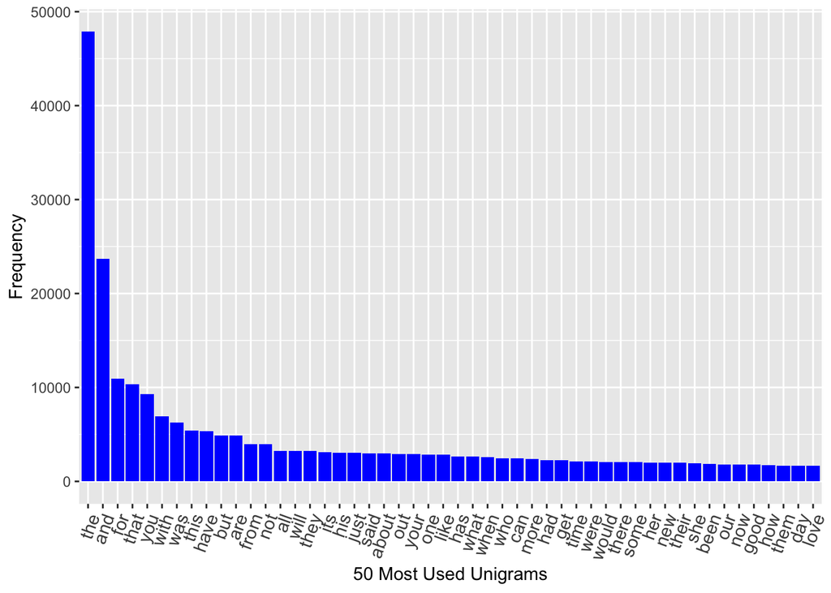

```r
plotFreq(freq1, "50 Most Used Unigrams")
```

##### 50 Most Used Bigrams

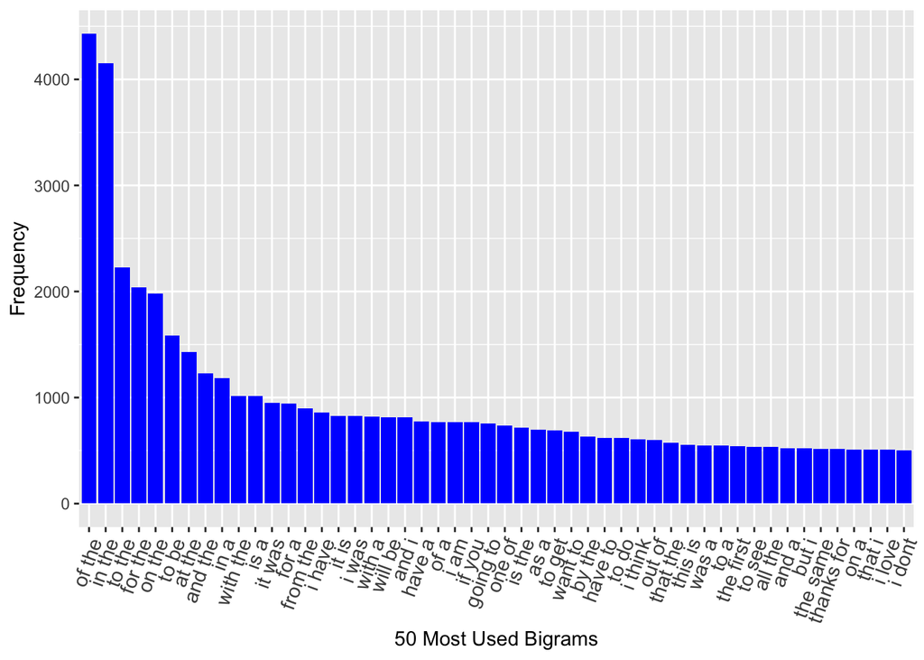

```r
plotFreq(freq2, "50 Most Used Bigrams")
```

##### 50 Most Used Trigrams

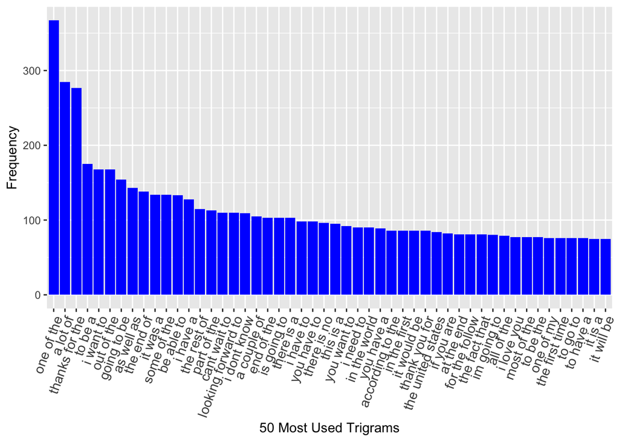

```r
plotFreq(freq3, "50 Most Used Trigrams")
```

## Next Steps For Prediction Algorithm And Shiny App

This concludes our exploritary analysis, as I expected most of the n-grams consisted of stopwords, which would be silly to get rid of when doing the model. My predictive algorithm will be using n-gram model with frequency lookup similar to our exploratory analysis above. The user interface of the Shiny app will consist of a text input box that will allow a user to enter a phrase. Then the app will use algorithm to suggest the most likely next word.